# Stat579 HW2

September 14, 2018

```r
# install.packages("alr3")
library(alr3)
library(tidyverse)
data(banknote)
banknote$Y <- factor(banknote$Y)
```

1. Use one of our object inspecting functions and interpret the result in the data that you see.

```r
summary(banknote)
```

```
##      Length           Left           Right           Bottom
##  Min.   :213.8   Min.   :129.0   Min.   :129.0   Min.   : 7.200
##  1st Qu.:214.6   1st Qu.:129.9   1st Qu.:129.7   1st Qu.: 8.200
##  Median :214.9   Median :130.2   Median :130.0   Median : 9.100
##  Mean   :214.9   Mean   :130.1   Mean   :130.0   Mean   : 9.418
##  3rd Qu.:215.1   3rd Qu.:130.4   3rd Qu.:130.2   3rd Qu.:10.600
##  Max.   :216.3   Max.   :131.0   Max.   :131.1   Max.   :12.700
##       Top           Diagonal     Y
##  Min.   : 7.70   Min.   :137.8   0:100
##  1st Qu.:10.10   1st Qu.:139.5   1:100
##  Median :10.60   Median :140.4
##  Mean   :10.65   Mean   :140.5
##  3rd Qu.:11.20   3rd Qu.:141.5
##  Max.   :12.30   Max.   :142.4
```

“Length” cateogry has the highest median compared to other categories, and “bottom” category has the lowest median and largest IQR. Y represents the number of bills in two categories (genuine and counterfeit), and the number of observations are exactly the same for both categories.

2. Barchart of Y

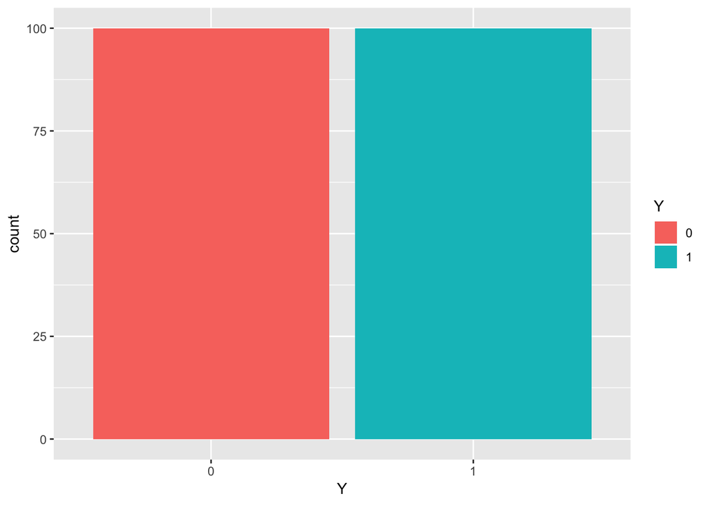

```r
ggplot(banknote, aes(Y, fill = Y)) + geom_bar()
```

Structure of the plot: it is a barplot to indicate the number of banknotes in two categories, genuine and counterfeit money. X represents the different categories of banknotes (genuine, counterfeit) and y axis is the number of observations in each category.

Main message of the plot: Total number of observations is 200, and the counts for each category are exactly the same (100 each).

Additional message: NA

3. Histogram of one of the variables in the dataset that shows a distinction between genuine and counterfeit banknotes.

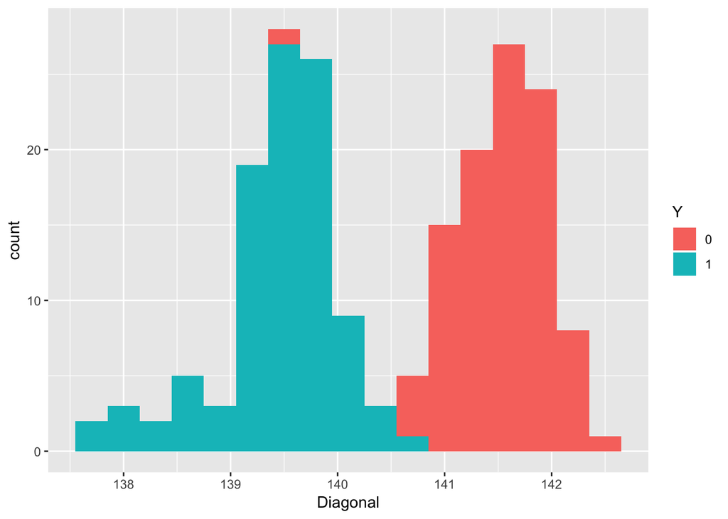

```r
ggplot(banknote, aes(Diagonal, fill = Y)) + geom_histogram(binwidth = 0.3)
```

Structure of the plot: Histrogram. X axis represents the diagonal legnth of each bill and Y axis represent the number of observations in each bin. The histogram is colored by genuine and counterfeit notes.

Main message of the plot: genuine notes are concentrated on the right end with a diagnoal length more than 140mm. Based on the plot, we can see that if a banknote has a diagonal length less than 140mm, it is reasonable to conclude that the note is counterfeit.

Additional message: We have some outliers in the histogram, but not that significant. We have a banknote with a diagonal length less than 140mm, and a counterfeit with a diagonal length more than 140mm.

4. A scatterplot of two (continuous) measurements, color by Y.

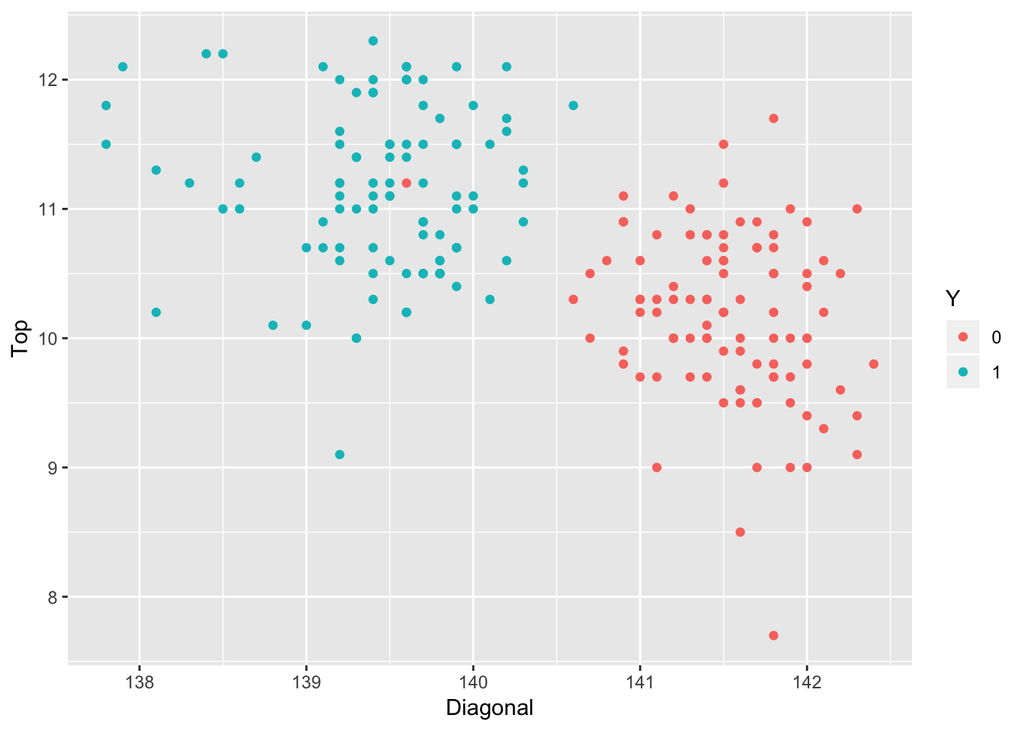

```r
ggplot(banknote, aes(x = Diagonal, y = Top, colour = Y)) + geom_point()
```

Structure of the plot: Scatterplot to see the association between two quantitative variables. X axis represents the diagnal legnth of each bill, and Y axis represents the Top margin width of each bill. The scatterplot is colored by genuine and counterfeit notes.

Main message of the plot: we do not see any strong linear association in the plot. However, we can see that genuine notes are more likely to have shorter top margin width with longer diagnoal length.

Additional message: We see couple of outliers in this plot.